# tutorial

## Harmony Py Tutorial

This notebook shows a basic example of a Harmony job using a Harmony test Collection to perform a combination of both spatial and temporal subsetting.

First, we import a few things that will help us create a request and display images. We then import the Harmony Py classes we need to make a request.

```python
import helper
# Install the project and 'examples' dependencies
helper.install_project_and_dependencies('..', libs=['examples'])

import sys
import datetime as dt
from IPython.display import display, JSON
import rasterio
import rasterio.plot
import netCDF4 as nc4
from matplotlib import pyplot as plt
import numpy as np

from harmony import BBox, WKT, Client, Collection, Request, Environment
```

Now we create a Harmony Client object, letting it pick up our credentials from a `.netrc` file.

```python
harmony_client = Client(env=Environment.UAT)
```

Next, let's create a Collection object with the [CMR](https://cmr.earthdata.nasa.gov/) collection id for the CMR collection we'd like to look at.

We then create a Request which specifies that collection, a `spatial` `BBox` describing the bounding box for the area we're interested in (we'll look at the `BBox` in other tutorials). In this case we're interested in looking at Alaska (and who wouldn't be?). We also include a date/time range to narrow down the data.

Because this data includes a lot of different variables, we limit it by passing in a list of `variable`s we're interested in; in this test collection we'll look at the blue variable. We include a `max_results` parameter to limit the results to the first 10 images just to get a sample of what things look like.

Next, we include a coordinate reference system (CRS) indicating we'd like to reproject the data into the [Arctic Polar Stereographic projection](https://epsg.io/3995). We also specify that we'd like the output to be in the GeoTIFF format with a resolution of 512x512 pixels.

Finally we check if the request we've created is valid.

```python
collection = Collection(id='C1234088182-EEDTEST')

request = Request(
    collection=collection,
    spatial=BBox(-165, 52, -140, 77),
    temporal={
        'start': dt.datetime(2010, 1, 1),
        'stop': dt.datetime(2020, 12, 30)
    },
    variables=['blue_var'],
    max_results=10,
    crs='EPSG:3995',
    format='image/tiff',
    height=512,
    width=512
)

request.is_valid()
```

```
True
```

Now that we have a request, we can submit it to Harmony using the Harmony Client object we created earlier. We'll get back an id for our request which we can use to find the job's status and get the results.

```python
job_id = harmony_client.submit(request)
```

Let's see how it's going. This will show the percentage complete in the `progress` field. (We use the JSON helper function to show the results in a nicer-to-look-at format).

```python
JSON(harmony_client.status(job_id))
```

[output not shown]

Let's download the results to our system temp directory, overwriting files if they already exist. This returns us a list of `Future` objects. Each of these "stand in" for a file in our set of results. We can ask a `Future` for its result and when it's available, it will return the filename to us.

```python
results = harmony_client.download_all(job_id, directory='/tmp', overwrite=True)
```

Allright, now let's show some colorful Alaska images! Here we iterate over the results, asking each `Future` for its result, and then using `rasterio` to open the file and display the image.

```
/tmp/9836438_2020_01_02_3200ff_global_blue_var_regridded_subsetted.nc.tif
```

```
/tmp/9836437_2020_01_01_7f00ff_global_blue_var_regridded_subsetted.nc.tif
```

```
/tmp/9836436_2020_01_01_7f00ff_global_blue_var_regridded_subsetted.nc.tif
```

```
/tmp/9836439_2020_01_03_0019ff_global_blue_var_regridded_subsetted.nc.tif
```

```
/tmp/9836440_2020_01_04_0065ff_global_blue_var_regridded_subsetted.nc.tif
```

```
/tmp/9836441_2020_01_05_00b2ff_global_blue_var_regridded_subsetted.nc.tif
```

```
/tmp/9836445_2020_01_09_00ff19_global_blue_var_regridded_subsetted.nc.tif
```

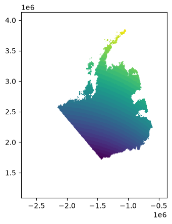

```
/tmp/9836444_2020_01_08_00ff66_global_blue_var_regridded_subsetted.nc.tif
```

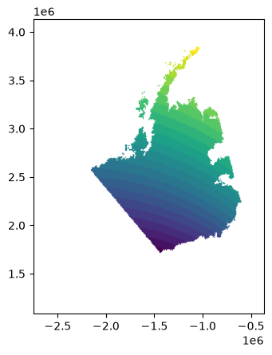

```
/tmp/9836442_2020_01_06_00feff_global_blue_var_regridded_subsetted.nc.tif
```

```
/tmp/9836443_2020_01_07_00ffb2_global_blue_var_regridded_subsetted.nc.tif
```

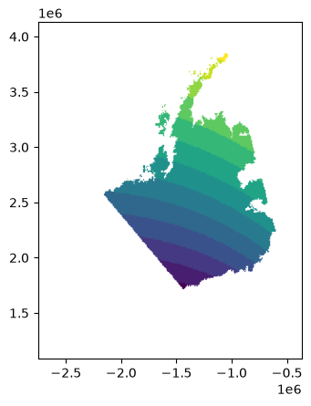

```python
for r in results:
    rasterio.plot.show(rasterio.open(r.result()))
```

We can also get a URL corresponding to our request that we can use in a browser. **Note:** This will not work if the request includes a shapefile.

```python
url = harmony_client.request_as_url(request)
print(url)
```

[output not shown]

Let's build another request. This time, we'll request a specific granule and grid using the UMM grid name from the CMR. You can find grids in the CMR at https://cmr.uat.earthdata.nasa.gov/search/grids.umm_json. Include a query parameter `?grid=LambertExample` to list detailed information about a specific grid.

```python
collection = Collection(id='C1233860183-EEDTEST')

request = Request(
    collection=collection,
    granule_id='G1233860486-EEDTEST',
    interpolation='near',
    grid='GEOS1x1test'
)

request.is_valid()
```

```
True
```

Submit the job and check on the status.

```python
job_id = harmony_client.submit(request)
JSON(harmony_client.status(job_id))
```

Download and plot the file using pyplot and numpy.

```
/tmp/9836447_002_02_028_europe_regridded.nc
```

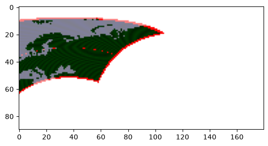

```python
results = harmony_client.download_all(job_id, directory='/tmp', overwrite=True)
nc4_file=nc4.Dataset(list(results)[0].result())
arrays = []
for var in ['red_var', 'green_var', 'blue_var', 'alpha_var']:
    ds = nc4_file.variables[var][0,:]
    arrays.append(ds)
plt.imshow(np.dstack(arrays))
```

```python
collection = Collection(id='C1233800302-EEDTEST')

request = Request(
    collection=collection,
    max_results=1,
    variables=['all']
)
response = harmony_client.submit(request)
response
```

```
'37482061-b782-432b-9687-1f9a02c48f37'
```

Download the result and show the file can be opened with NetCDF library.

```python
results = harmony_client.download_all(response, directory='/tmp', overwrite=True)
file_names = [f.result() for f in results]
for filename in file_names:
    if filename.endswith("nc"):
        print(nc4.Dataset(filename))
```

```
/tmp/001_00_7f00ff_global.nc
```

```
/tmp/001_00_7f00ff_global.tif
<class 'netCDF4.Dataset'>
root group (NETCDF4 data model, file format HDF5):
    GDAL_AREA_OR_POINT: Area
    GDAL_HARMONY_HEX_COLOR: 7f00ff
    GDAL_HARMONY_HUE: 0.75
    Conventions: CF-1.5
    GDAL: GDAL 3.2.0, released 2020/10/26
    history: Fri May 27 16:34:47 2022: GDAL CreateCopy( out/nc/001_00_7f00ff_global.nc, ... )
    dimensions(sizes): lon(3600), lat(1800)
    variables(dimensions): |S1 crs(), float64 lat(lat), float64 lon(lon), uint8 red_var(lat, lon), uint8 green_var(lat, lon), uint8 blue_var(lat, lon), uint8 alpha_var(lat, lon)
    groups:
```

Example of submitting a request with WKT spatial. The supported WKT geometry types are listed at: https://harmony-py.readthedocs.io/en/latest/api.html#harmony.harmony.WKT

```python
collection = Collection(id='C1233800302-EEDTEST')

request = Request(
    collection=collection,
    spatial=WKT('POLYGON((-140 20, -50 20, -50 60, -140 60, -140 20))'),
    granule_id=['C1233800302-EEDTEST'],
    max_results=1,
    temporal={
        'start': dt.datetime(1980, 1, 1),
        'stop': dt.datetime(2020, 12, 30)
    },
    variables=['blue_var'],
    crs='EPSG:31975',
    format='image/png'
)

request.is_valid()
```

```
True
```

```python
response = harmony_client.submit(request)
response
```

```
'03cf4080-bd2e-4f5f-b27d-1c708e98ab1b'
```

Show the result:

```
/tmp/9836450_001_00_7f00ff_global_blue_var_regridded.nc.png

  /tmp/9836450_001_00_7f00ff_global_blue_var_regridded.nc.png
```

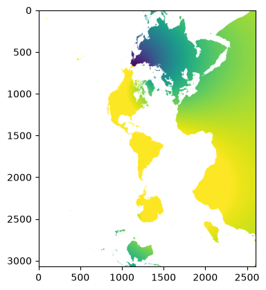

```python
for filename in [f.result() for f in harmony_client.download_all(response, directory='/tmp', overwrite=True)]:
    if filename.endswith("png"):
        helper.show_result(filename)
```